# travail Pracma

vincent obertelli

12/7/2020

Maintenant nous allons voir la librairie Pracma. Cette librairie propose un large panel de fonction, allant de l’analyse numérique en passant par différentes équations (algébre numéraire, optimisation numérique, …)

Pour commencer, nous allons installer la bibliothèque : install.packages(“pracma”)

Pour commencer, voila ce qui est possible en utilisant la librairie Pracma. On peut travailler sur des problèmes mathématiques complexes et proposer des visuels pour mieux les comprendre.

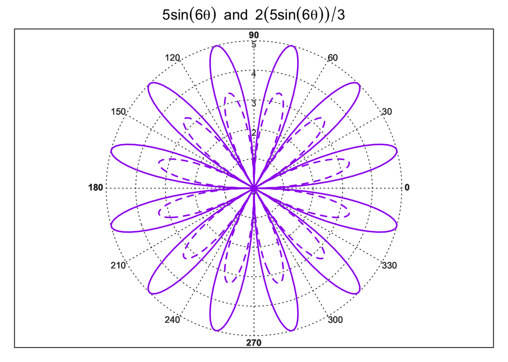

```r
 library(pracma)
 t=seq(0,2*pi, length=360)
 f=function(t){5*sin(6*t)}
 par(mar=c(1,1,2,1))
 polar(t,f(t),grcol="gray20",bxcol="black",col="purple",
lwd=2,main=expression(5*sin(6*theta)~ ~"and"~ ~
2(5*sin(6*theta))/3))
 polar(t,2*f(t)/3,col="purple",lty=2,lwd=2,add=TRUE)
```

Maintenant, nous allons voir les fonctions de base de cette librairie :

**abm3pc**. Cette fonction est une fonction d’approche prédicitive. Elle contient les arguments suivants :

**f**, fonction différentiel

**a, b**, l’interval

**Y0**, valeur de début

**n**, nombre de valeur

**…**, paramètres additionnels

Maintenant, voici la fonction : abm3pc(f, a, b, y0, n = 50, …)

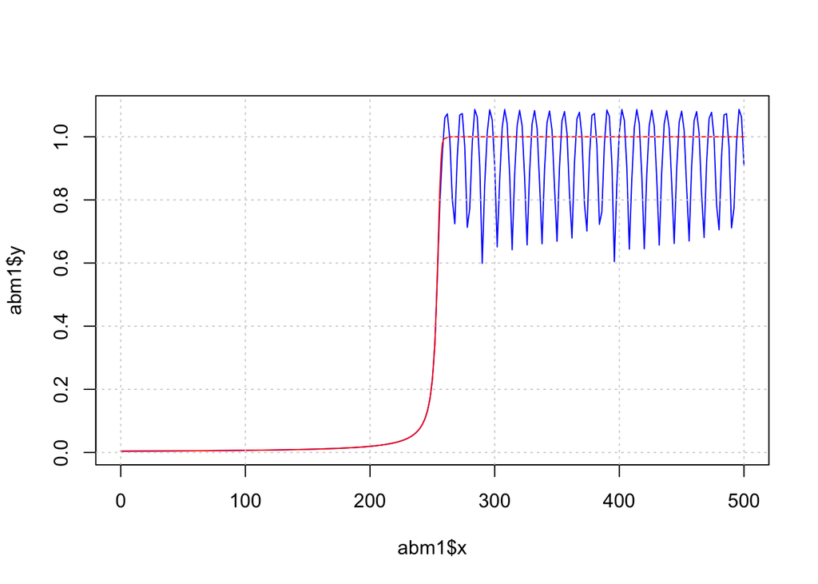

```r
library(pracma)
 #   y' = y^2 - y^3, y(0) = d, 0 <= t <= 2/d, d = 0.01
    f <- function(t, y) y^2 - y^3
    d <- 1/250
    abm1 <- abm3pc(f, 0, 2/d, d, n = 1/d)
    abm2 <- abm3pc(f, 0, 2/d, d, n = 2/d)
    ## Not run:
    plot(abm1$x, abm1$y, type = "l", col = "blue")
    lines(abm2$x, abm2$y, type = "l", col = "red")
    grid()
```

Nous allons désormais voir la fonction **agmean**. Cette fonction permet de calculer la moyenne.

On l’utilise de cette manière : agmean(a, b).

a et b sont des vecteurs de nombres réels ou complexes de même longeur.

Voila un exemple de comment utiliser cette fonction :

```r
library(pracma)
agmean(1, sqrt(2))$agm - 0.834626841674073186
```

```
## [1] 0.3635134
```

maintenant, nous allons voir **accumarray**. Cette fonction permet de grouper des éléments d’un data set et d’appliquer une fonction pour chaque groupe.

Voila à quoi ressemble l’expression : accumarray(subs, val, sz = NULL, func = sum, fillval = 0)

**subs**, vecteur ou matrice

**val**, vecteur numérique

**sz**, taille du array

**func**, la fonction à appliquer aux nombres vecteurs

**fillval**, valeur utilisées pour remplir le array

**a**, valeur numérique

```r
library(pracma)
 ## exemple
    val = 101:105
    subs = as.matrix(c(1, 2, 4, 2, 4))
    accumarray(subs, val)
```

```
##      [,1]
## [1,]  101
## [2,]  206
## [3,]    0
## [4,]  208
```

Enfin, nous allons voir les fonctions **and** et **or**. Comme leur noms l’indique, il s’agit de “et” et “ou”.

```r
library(pracma)
A <- matrix(c(0.5,  0.5,  0, 0.75, 0,
                  0.5,  0, 0.75, 0.05, 0.85,
                  0.35, 0, 0,  0,  0.01,
                  0.5,  0.65, 0.65, 0.05, 0), 4, 5,
            byrow=TRUE)

    B <- matrix(c( 0, 1, 0, 1, 0,
                   1, 1, 1, 0, 1,
                   0, 1, 1, 1, 0,
                   0, 1, 0, 0, 1), 4, 5, byrow=TRUE)

and(A, B)
```

```
##      [,1] [,2] [,3] [,4] [,5]
## [1,]    0    1    0    1    0
## [2,]    1    0    1    0    1
## [3,]    0    0    0    0    0
## [4,]    0    1    0    0    0
```

```r
or(A, B)
```

```
##      [,1] [,2] [,3] [,4] [,5]
## [1,]    1    1    0    1    0
## [2,]    1    1    1    1    1
## [3,]    1    1    1    1    1
## [4,]    1    1    1    1    1
```